# Image Classification with Keras

4/28/2021

## What is Keras?

Keras is a high-level neural networks API developed with a focus on enabling fast experimentation.

- Allows the same code to run on CPU or on GPU, seamlessly.
- User-friendly API which makes it easy to quickly prototype deep learning models.
- Built-in support for convolutional networks (for computer vision), recurrent networks (for sequence processing), and any combination of both.
- Supports arbitrary network architectures: multi-input or multi-output models, layer sharing, model sharing, etc. This means that Keras is appropriate for building essentially any deep learning model, from a memory network to a neural Turing machine.(Falbel 2021)

## Installation of Tensorflow and Keras

In order to use Keras we need to install it. Instructions can be found on the [R-Studio Website](https://keras.rstudio.com/reference/install_keras.html). However, it is as simple as running the following commands. (Falbel, Chollet, and Allaire, n.d.).

```r
install.packages("keras")
library(keras)
install_keras()
```

## The Sample Dataset

For this presentation I will be using the MNIST Dataset(LeCun, Cortes, and Burges, n.d.). This is comprised of a training set of 60,000 examples of hand written digits, and a testing set of 10,000 digits. I will be using Keras to create a classification model for this dataset.(Allaire, n.d.)

[figure not shown]

Examples from Dataset

## Load the Dataset

```r
mnist_data <- dataset_mnist()

train_data_images <- mnist_data$train$x
train_data_classification <- mnist_data$train$y

test_data_image <- mnist_data$test$x
test_data_classification <- mnist_data$test$y
```

## Resize Images for Model

```r
train_data_images <- array_reshape(train_data_images, c(nrow(train_data_images), 784))
test_data_image <- array_reshape( test_data_image, c(nrow(test_data_image), 784) )

train_data_classification <- to_categorical(train_data_classification, 10)
test_data_classification <- to_categorical(test_data_classification, 10)
```

## Create Model

```r
model <- keras_model_sequential()
model %>%
  layer_dense(units = 256, activation = 'relu', input_shape = c(784)) %>%
  layer_dropout(rate = 0.4) %>%
  layer_dense(units = 128, activation = 'relu') %>%
  layer_dropout(rate = 0.3) %>%
  layer_dense(units = 10, activation = 'softmax')
```

(Allaire, n.d.)

## Compile Model

```r
model %>% compile(
  loss = 'categorical_crossentropy',
  optimizer = optimizer_rmsprop(),
  metrics = c('accuracy')
)
```

(Allaire, n.d.)

## Fit Model

```r
history <- model %>% fit(
  train_data_images, train_data_classification,
  epochs = 30, batch_size = 128,
  validation_split = 0.2
)
```

## Fit Model Plot

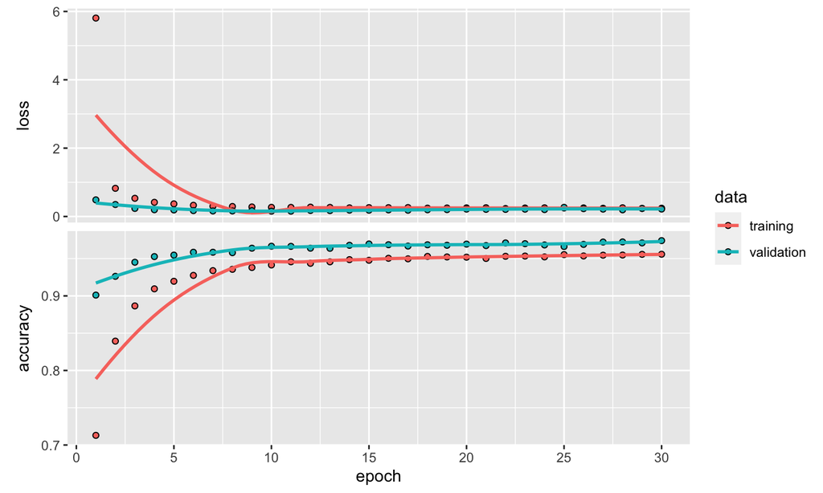

(Allaire, n.d.)

## Testing Model

```r
model %>% evaluate(test_data_image, test_data_classification)
```

```
##      loss  accuracy
## 0.2732784 0.9706000
```

(Allaire, n.d.)

## Show Predicted Classes

```r
model %>% predict_classes(test_data_image)
```

```
##     [1] 7 2 1 0 4 1 4 9 5 9 0 6 9 0 1 5 9 7 3 4 9 6 6 5 4 0 7 4 0 1 3 1 3 4 7 2
##    [37] 7 1 2 1 1 7 4 2 3 5 1 2 4 4 6 3 5 5 6 0 4 1 9 5 7 8 9 3 7 4 6 4 3 0 7 0
##    [73] 2 9 1 7 3 2 9 7 7 6 2 7 8 4 7 3 6 1 3 6 9 3 1 4 1 7 6 9 6 0 5 4 9 9 2 1
##   [109] 9 4 8 7 3 9 7 4 4 4 9 2 5 4 7 6 7 9 0 5 8 5 6 6 5 7 8 1 0 1 6 4 6 7 3 1
##   [145] 7 1 8 2 0 3 9 9 5 5 1 5 6 0 3 4 4 6 5 4 6 5 4 5 1 4 4 7 2 3 2 7 1 8 1 8
##   [181] 1 8 5 0 8 9 2 5 0 1 1 1 0 9 0 3 1 6 4 2 8 6 1 1 1 3 9 5 2 9 4 5 9 3 9 0
##   [217] 3 6 5 5 7 2 2 7 1 2 8 4 1 7 3 3 8 8 7 9 2 2 4 1 5 8 8 7 2 3 0 6 4 2 4 1
##   [253] 9 5 7 7 2 8 2 0 8 5 7 7 9 1 8 1 8 0 3 0 1 9 9 4 1 8 2 1 2 9 7 5 9 2 6 4
##   [289] 1 5 8 2 9 2 0 4 0 0 2 8 4 7 1 2 4 0 2 7 4 3 3 0 0 3 1 9 6 5 2 5 9 7 9 3
##   [325] 0 4 2 0 7 1 1 2 1 5 3 3 9 7 8 6 5 6 1 3 8 1 0 5 1 3 1 5 5 6 1 8 5 1 7 9
##   [361] 4 6 2 2 5 0 6 5 6 3 7 2 0 8 8 5 4 1 1 4 0 3 3 7 6 1 6 2 1 9 2 8 6 1 9 5
##   [397] 2 5 4 4 2 8 3 8 2 4 8 0 3 1 7 7 3 7 9 7 1 9 2 1 4 0 9 2 0 4 9 1 4 8 1 8
##   [433] 4 5 9 8 8 3 7 6 0 0 3 0 2 0 6 9 9 3 3 3 2 3 9 1 2 6 8 0 9 6 6 6 3 8 8 2
##   [469] 7 5 8 9 6 1 8 4 1 2 5 9 1 9 7 5 4 0 8 9 9 1 0 5 2 3 7 8 9 4 0 6 3 9 5 2
##   [505] 1 3 1 3 6 5 7 4 2 2 6 3 2 6 5 4 8 9 7 1 3 0 3 8 3 1 9 3 4 4 6 4 2 1 8 2
```

[output cut: 263 more lines]

(Allaire, n.d.)

## References

Allaire, J. J. n.d. *TensorFlow for R*. RStudio. https://tensorflow.rstudio.com/tutorials/beginners/.

Falbel, Daniel. 2021. *Getting Started with Keras*. CRAN. https://cran.r-project.org/web/packages/keras/vignettes/index.html.

Falbel, Daniel, François Chollet, and JJ Allaire. n.d. “Install Keras and the TensorFlow.” RStudio. https://keras.rstudio.com/reference/install_keras.html.

LeCun, Yann, Corinna Cortes, and Christopher J. C. Burges. n.d. “THE MNIST DATABASE.” *MNIST Handwritten Digit Database, Yann LeCun, Corinna Cortes and Chris Burges*. http://yann.lecun.com/exdb/mnist/.